# Optimal Treatment Analysis

## Outcome Variable

**Outcome Variable:** whz

## Predictor Variables

**Intervention Variable:** hfoodsec

**Adjustment Set:**

- arm
- sex
- W_mage
- meducyrs
- feducyrs
- hhwealth_quart
- vagbrth
- W_nrooms
- W_nchldlt5
- brthmon
- W_parity
- impfloor
- impsan
- safeh20
- delta_W_mage
- delta_meducyrs
- delta_feducyrs
- delta_hhwealth_quart
- delta_vagbrth
- delta_W_nrooms
- delta_W_nchldlt5
- delta_brthmon
- delta_W_parity
- delta_impfloor
- delta_impsan
- delta_safeh20

## Stratifying Variables

The analysis was stratified on these variable(s):

- agecat
- studyid
- country

## Data Summary

| agecat | studyid | country | hfoodsec | n_cell | n |
| --- | --- | --- | --- | --- | --- |
| Birth | ki0047075b-MAL-ED | BANGLADESH | Food Secure | 138 | 162 |
| Birth | ki0047075b-MAL-ED | BANGLADESH | Mildly Food Insecure | 3 | 162 |
| Birth | ki0047075b-MAL-ED | BANGLADESH | Food Insecure | 21 | 162 |
| Birth | ki0047075b-MAL-ED | BRAZIL | Food Secure | 0 | 26 |
| Birth | ki0047075b-MAL-ED | BRAZIL | Mildly Food Insecure | 4 | 26 |
| Birth | ki0047075b-MAL-ED | BRAZIL | Food Insecure | 22 | 26 |
| Birth | ki0047075b-MAL-ED | INDIA | Food Secure | 32 | 35 |
| Birth | ki0047075b-MAL-ED | INDIA | Mildly Food Insecure | 1 | 35 |
| Birth | ki0047075b-MAL-ED | INDIA | Food Insecure | 2 | 35 |
| Birth | ki0047075b-MAL-ED | NEPAL | Food Secure | 10 | 14 |
| Birth | ki0047075b-MAL-ED | NEPAL | Mildly Food Insecure | 1 | 14 |
| Birth | ki0047075b-MAL-ED | NEPAL | Food Insecure | 3 | 14 |
| Birth | ki0047075b-MAL-ED | PERU | Food Secure | 23 | 89 |
| Birth | ki0047075b-MAL-ED | PERU | Mildly Food Insecure | 22 | 89 |
| Birth | ki0047075b-MAL-ED | PERU | Food Insecure | 44 | 89 |
| Birth | ki0047075b-MAL-ED | SOUTH AFRICA | Food Secure | 45 | 87 |
| Birth | ki0047075b-MAL-ED | SOUTH AFRICA | Mildly Food Insecure | 9 | 87 |
| Birth | ki0047075b-MAL-ED | SOUTH AFRICA | Food Insecure | 33 | 87 |
| Birth | ki1017093-NIH-Birth | BANGLADESH | Food Secure | 86 | 575 |
| Birth | ki1017093-NIH-Birth | BANGLADESH | Mildly Food Insecure | 453 | 575 |
| Birth | ki1017093-NIH-Birth | BANGLADESH | Food Insecure | 36 | 575 |
| Birth | ki1017093c-NIH-Crypto | BANGLADESH | Food Secure | 429 | 707 |
| Birth | ki1017093c-NIH-Crypto | BANGLADESH | Mildly Food Insecure | 199 | 707 |
| Birth | ki1017093c-NIH-Crypto | BANGLADESH | Food Insecure | 79 | 707 |
| Birth | ki1113344-GMS-Nepal | NEPAL | Food Secure | 442 | 620 |
| Birth | ki1113344-GMS-Nepal | NEPAL | Mildly Food Insecure | 100 | 620 |
| Birth | ki1113344-GMS-Nepal | NEPAL | Food Insecure | 78 | 620 |
| Birth | kiGH5241-JiVitA-3 | BANGLADESH | Food Secure | 5797 | 11763 |
| Birth | kiGH5241-JiVitA-3 | BANGLADESH | Mildly Food Insecure | 3947 | 11763 |
| Birth | kiGH5241-JiVitA-3 | BANGLADESH | Food Insecure | 2019 | 11763 |

[output cut: 69 more lines]

The following strata were considered:

- agecat: 24 months, studyid: ki0047075b-MAL-ED, country: BANGLADESH
- agecat: 24 months, studyid: ki0047075b-MAL-ED, country: BRAZIL
- agecat: 24 months, studyid: ki0047075b-MAL-ED, country: INDIA
- agecat: 24 months, studyid: ki0047075b-MAL-ED, country: NEPAL
- agecat: 24 months, studyid: ki0047075b-MAL-ED, country: PERU
- agecat: 24 months, studyid: ki0047075b-MAL-ED, country: SOUTH AFRICA
- agecat: 24 months, studyid: ki1017093-NIH-Birth, country: BANGLADESH
- agecat: 24 months, studyid: ki1017093c-NIH-Crypto, country: BANGLADESH
- agecat: 24 months, studyid: ki1113344-GMS-Nepal, country: NEPAL
- agecat: 24 months, studyid: kiGH5241-JiVitA-3, country: BANGLADESH
- agecat: 24 months, studyid: kiGH5241-JiVitA-4, country: BANGLADESH
- agecat: 6 months, studyid: ki0047075b-MAL-ED, country: BANGLADESH
- agecat: 6 months, studyid: ki0047075b-MAL-ED, country: BRAZIL
- agecat: 6 months, studyid: ki0047075b-MAL-ED, country: INDIA
- agecat: 6 months, studyid: ki0047075b-MAL-ED, country: NEPAL
- agecat: 6 months, studyid: ki0047075b-MAL-ED, country: PERU
- agecat: 6 months, studyid: ki0047075b-MAL-ED, country: SOUTH AFRICA
- agecat: 6 months, studyid: ki1017093-NIH-Birth, country: BANGLADESH
- agecat: 6 months, studyid: ki1017093c-NIH-Crypto, country: BANGLADESH
- agecat: 6 months, studyid: ki1113344-GMS-Nepal, country: NEPAL
- agecat: 6 months, studyid: kiGH5241-JiVitA-3, country: BANGLADESH
- agecat: 6 months, studyid: kiGH5241-JiVitA-4, country: BANGLADESH
- agecat: Birth, studyid: ki0047075b-MAL-ED, country: BANGLADESH
- agecat: Birth, studyid: ki0047075b-MAL-ED, country: BRAZIL
- agecat: Birth, studyid: ki0047075b-MAL-ED, country: INDIA
- agecat: Birth, studyid: ki0047075b-MAL-ED, country: NEPAL
- agecat: Birth, studyid: ki0047075b-MAL-ED, country: PERU
- agecat: Birth, studyid: ki0047075b-MAL-ED, country: SOUTH AFRICA
- agecat: Birth, studyid: ki1017093-NIH-Birth, country: BANGLADESH
- agecat: Birth, studyid: ki1017093c-NIH-Crypto, country: BANGLADESH
- agecat: Birth, studyid: ki1113344-GMS-Nepal, country: NEPAL
- agecat: Birth, studyid: kiGH5241-JiVitA-3, country: BANGLADESH
- agecat: Birth, studyid: kiGH5241-JiVitA-4, country: BANGLADESH

### Dropped Strata

Some strata were dropped due to rare outcomes:

- agecat: Birth, studyid: ki0047075b-MAL-ED, country: BANGLADESH
- agecat: Birth, studyid: ki0047075b-MAL-ED, country: BRAZIL
- agecat: Birth, studyid: ki0047075b-MAL-ED, country: INDIA
- agecat: Birth, studyid: ki0047075b-MAL-ED, country: NEPAL
- agecat: 6 months, studyid: ki0047075b-MAL-ED, country: BANGLADESH
- agecat: 6 months, studyid: ki0047075b-MAL-ED, country: BRAZIL
- agecat: 24 months, studyid: ki0047075b-MAL-ED, country: BANGLADESH
- agecat: 24 months, studyid: ki0047075b-MAL-ED, country: BRAZIL

## Methods Detail

We’re interested in the causal parameters $E[Y_a]$ for all values of $a \in \mathcal{A}$. These parameters represent the mean outcome if, possibly contrary to fact, we intervened to set all units to have $A=a$. Under the randomization and positivity assumptions, these are identified by the statistical parameters $\psi_a=E_W[E_{Y|A,W}(Y|A=a,W)]$. In addition, we’re interested in the mean of $Y$, $E[Y]$ under no intervention (the observed mean). We will estimate these parameters by using SuperLearner to fit the relevant likelihood factors – $E_{Y|A,W}(Y|A=a,W)$ and $p(A=a|W)$, and then updating our likelihood fit using a joint TMLE.

For unadjusted analyses ($W=\{\}$), initial likelihoods were estimated using Lrnr_glm to estimate the simple $E(Y|A)$ and Lrnr_mean to estimate $p(A)$. For adjusted analyses, a small library containing Lrnr_glmnet, Lrnr_xgboost, and Lrnr_mean was used.

Having estimated these parameters, we will then use the delta method to estimate relative risks and attributable risks relative to a prespecified baseline level of $A$.

# Results Detail

## Results Plots

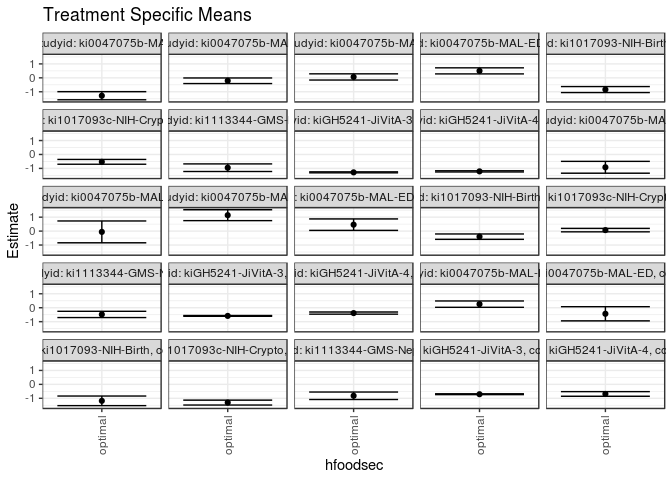

## Results Table

### Parameter: TSM

| agecat | studyid | country | intervention_level | baseline_level | estimate | ci_lower | ci_upper |
| --- | --- | --- | --- | --- | --- | --- | --- |
| Birth | ki0047075b-MAL-ED | PERU | optimal | observed | 0.2573269 | 0.0303950 | 0.4842588 |
| Birth | ki0047075b-MAL-ED | SOUTH AFRICA | optimal | observed | -0.4338991 | -0.9417616 | 0.0739633 |
| Birth | ki1017093-NIH-Birth | BANGLADESH | optimal | observed | -1.1809972 | -1.5256821 | -0.8363123 |
| Birth | ki1017093c-NIH-Crypto | BANGLADESH | optimal | observed | -1.3063457 | -1.4820091 | -1.1306824 |
| Birth | ki1113344-GMS-Nepal | NEPAL | optimal | observed | -0.8177268 | -1.0845556 | -0.5508979 |
| Birth | kiGH5241-JiVitA-3 | BANGLADESH | optimal | observed | -0.7066364 | -0.7378289 | -0.6754438 |
| Birth | kiGH5241-JiVitA-4 | BANGLADESH | optimal | observed | -0.6878130 | -0.8544629 | -0.5211631 |
| 6 months | ki0047075b-MAL-ED | INDIA | optimal | observed | -0.9187807 | -1.3431639 | -0.4943975 |
| 6 months | ki0047075b-MAL-ED | NEPAL | optimal | observed | -0.0561594 | -0.8388603 | 0.7265415 |
| 6 months | ki0047075b-MAL-ED | PERU | optimal | observed | 1.1410710 | 0.7497712 | 1.5323707 |
| 6 months | ki0047075b-MAL-ED | SOUTH AFRICA | optimal | observed | 0.4613381 | 0.0497725 | 0.8729038 |
| 6 months | ki1017093-NIH-Birth | BANGLADESH | optimal | observed | -0.3973944 | -0.5898397 | -0.2049491 |
| 6 months | ki1017093c-NIH-Crypto | BANGLADESH | optimal | observed | 0.0701822 | -0.0529069 | 0.1932712 |
| 6 months | ki1113344-GMS-Nepal | NEPAL | optimal | observed | -0.4808046 | -0.7055228 | -0.2560864 |
| 6 months | kiGH5241-JiVitA-3 | BANGLADESH | optimal | observed | -0.5858576 | -0.6150032 | -0.5567121 |
| 6 months | kiGH5241-JiVitA-4 | BANGLADESH | optimal | observed | -0.3844545 | -0.4622752 | -0.3066338 |
| 24 months | ki0047075b-MAL-ED | INDIA | optimal | observed | -1.2827787 | -1.5732722 | -0.9922853 |
| 24 months | ki0047075b-MAL-ED | NEPAL | optimal | observed | -0.2102220 | -0.4105087 | -0.0099353 |
| 24 months | ki0047075b-MAL-ED | PERU | optimal | observed | 0.0645376 | -0.1585227 | 0.2875978 |
| 24 months | ki0047075b-MAL-ED | SOUTH AFRICA | optimal | observed | 0.5002853 | 0.2826268 | 0.7179438 |
| 24 months | ki1017093-NIH-Birth | BANGLADESH | optimal | observed | -0.8398917 | -1.0550728 | -0.6247105 |
| 24 months | ki1017093c-NIH-Crypto | BANGLADESH | optimal | observed | -0.5296220 | -0.7015843 | -0.3576598 |
| 24 months | ki1113344-GMS-Nepal | NEPAL | optimal | observed | -0.9495871 | -1.2211896 | -0.6779846 |
| 24 months | kiGH5241-JiVitA-3 | BANGLADESH | optimal | observed | -1.2828860 | -1.3177556 | -1.2480164 |
| 24 months | kiGH5241-JiVitA-4 | BANGLADESH | optimal | observed | -1.2121161 | -1.2566992 | -1.1675331 |

### Parameter: E(Y)

| agecat | studyid | country | intervention_level | baseline_level | estimate | ci_lower | ci_upper |
| --- | --- | --- | --- | --- | --- | --- | --- |
| Birth | ki0047075b-MAL-ED | PERU | observed | observed | -0.0483146 | -0.2475806 | 0.1509514 |
| Birth | ki0047075b-MAL-ED | SOUTH AFRICA | observed | observed | -0.1502299 | -0.4075620 | 0.1071022 |
| Birth | ki1017093-NIH-Birth | BANGLADESH | observed | observed | -1.3499217 | -1.4444634 | -1.2553801 |
| Birth | ki1017093c-NIH-Crypto | BANGLADESH | observed | observed | -1.2441513 | -1.3281130 | -1.1601897 |
| Birth | ki1113344-GMS-Nepal | NEPAL | observed | observed | -1.1165161 | -1.2055683 | -1.0274639 |
| Birth | kiGH5241-JiVitA-3 | BANGLADESH | observed | observed | -0.7508875 | -0.7730765 | -0.7286985 |
| Birth | kiGH5241-JiVitA-4 | BANGLADESH | observed | observed | -0.6898154 | -0.7422632 | -0.6373675 |
| 6 months | ki0047075b-MAL-ED | INDIA | observed | observed | -0.7220008 | -0.8576809 | -0.5863207 |
| 6 months | ki0047075b-MAL-ED | NEPAL | observed | observed | 0.1277734 | -0.0649431 | 0.3204900 |
| 6 months | ki0047075b-MAL-ED | PERU | observed | observed | 0.9819369 | 0.7674415 | 1.1964324 |
| 6 months | ki0047075b-MAL-ED | SOUTH AFRICA | observed | observed | 0.5429020 | 0.3813518 | 0.7044523 |
| 6 months | ki1017093-NIH-Birth | BANGLADESH | observed | observed | -0.4474038 | -0.5378167 | -0.3569909 |
| 6 months | ki1017093c-NIH-Crypto | BANGLADESH | observed | observed | 0.0297622 | -0.0491685 | 0.1086930 |
| 6 months | ki1113344-GMS-Nepal | NEPAL | observed | observed | -0.6018803 | -0.6892284 | -0.5145323 |
| 6 months | kiGH5241-JiVitA-3 | BANGLADESH | observed | observed | -0.5932301 | -0.6127836 | -0.5736767 |
| 6 months | kiGH5241-JiVitA-4 | BANGLADESH | observed | observed | -0.3895527 | -0.4270314 | -0.3520739 |
| 24 months | ki0047075b-MAL-ED | INDIA | observed | observed | -0.9588679 | -1.0774868 | -0.8402491 |
| 24 months | ki0047075b-MAL-ED | NEPAL | observed | observed | -0.2730469 | -0.4358169 | -0.1102769 |
| 24 months | ki0047075b-MAL-ED | PERU | observed | observed | 0.0982009 | -0.0794754 | 0.2758773 |
| 24 months | ki0047075b-MAL-ED | SOUTH AFRICA | observed | observed | 0.4080227 | 0.2828348 | 0.5332106 |
| 24 months | ki1017093-NIH-Birth | BANGLADESH | observed | observed | -0.9115790 | -1.0095022 | -0.8136559 |
| 24 months | ki1017093c-NIH-Crypto | BANGLADESH | observed | observed | -0.6103502 | -0.7050157 | -0.5156847 |
| 24 months | ki1113344-GMS-Nepal | NEPAL | observed | observed | -1.1304997 | -1.2205265 | -1.0404728 |
| 24 months | kiGH5241-JiVitA-3 | BANGLADESH | observed | observed | -1.2988352 | -1.3224626 | -1.2752078 |
| 24 months | kiGH5241-JiVitA-4 | BANGLADESH | observed | observed | -1.2243590 | -1.2566569 | -1.1920612 |

### Parameter: PAR

| agecat | studyid | country | intervention_level | baseline_level | estimate | ci_lower | ci_upper |
| --- | --- | --- | --- | --- | --- | --- | --- |
| Birth | ki0047075b-MAL-ED | PERU | optimal | observed | -0.3056415 | -0.5265212 | -0.0847618 |
| Birth | ki0047075b-MAL-ED | SOUTH AFRICA | optimal | observed | 0.2836693 | -0.1053202 | 0.6726587 |
| Birth | ki1017093-NIH-Birth | BANGLADESH | optimal | observed | -0.1689246 | -0.4952319 | 0.1573827 |
| Birth | ki1017093c-NIH-Crypto | BANGLADESH | optimal | observed | 0.0621944 | -0.0864974 | 0.2108861 |
| Birth | ki1113344-GMS-Nepal | NEPAL | optimal | observed | -0.2987894 | -0.5452350 | -0.0523437 |
| Birth | kiGH5241-JiVitA-3 | BANGLADESH | optimal | observed | -0.0442512 | -0.0666840 | -0.0218184 |
| Birth | kiGH5241-JiVitA-4 | BANGLADESH | optimal | observed | -0.0020024 | -0.1521918 | 0.1481870 |
| 6 months | ki0047075b-MAL-ED | INDIA | optimal | observed | 0.1967799 | -0.1980856 | 0.5916455 |
| 6 months | ki0047075b-MAL-ED | NEPAL | optimal | observed | 0.1839328 | -0.5402848 | 0.9081505 |
| 6 months | ki0047075b-MAL-ED | PERU | optimal | observed | -0.1591341 | -0.4646429 | 0.1463748 |
| 6 months | ki0047075b-MAL-ED | SOUTH AFRICA | optimal | observed | 0.0815639 | -0.2783454 | 0.4414733 |
| 6 months | ki1017093-NIH-Birth | BANGLADESH | optimal | observed | -0.0500094 | -0.2267214 | 0.1267026 |
| 6 months | ki1017093c-NIH-Crypto | BANGLADESH | optimal | observed | -0.0404199 | -0.1336237 | 0.0527838 |
| 6 months | ki1113344-GMS-Nepal | NEPAL | optimal | observed | -0.1210758 | -0.3349978 | 0.0928463 |
| 6 months | kiGH5241-JiVitA-3 | BANGLADESH | optimal | observed | -0.0073725 | -0.0279849 | 0.0132399 |
| 6 months | kiGH5241-JiVitA-4 | BANGLADESH | optimal | observed | -0.0050982 | -0.0733300 | 0.0631336 |
| 24 months | ki0047075b-MAL-ED | INDIA | optimal | observed | 0.3239108 | 0.0504070 | 0.5974146 |
| 24 months | ki0047075b-MAL-ED | NEPAL | optimal | observed | -0.0628249 | -0.1577309 | 0.0320812 |
| 24 months | ki0047075b-MAL-ED | PERU | optimal | observed | 0.0336634 | -0.1872256 | 0.2545524 |
| 24 months | ki0047075b-MAL-ED | SOUTH AFRICA | optimal | observed | -0.0922627 | -0.2658882 | 0.0813629 |
| 24 months | ki1017093-NIH-Birth | BANGLADESH | optimal | observed | -0.0716874 | -0.2705752 | 0.1272005 |
| 24 months | ki1017093c-NIH-Crypto | BANGLADESH | optimal | observed | -0.0807282 | -0.2265482 | 0.0650919 |
| 24 months | ki1113344-GMS-Nepal | NEPAL | optimal | observed | -0.1809126 | -0.4320266 | 0.0702014 |
| 24 months | kiGH5241-JiVitA-3 | BANGLADESH | optimal | observed | -0.0159491 | -0.0408158 | 0.0089175 |
| 24 months | kiGH5241-JiVitA-4 | BANGLADESH | optimal | observed | -0.0122429 | -0.0435792 | 0.0190934 |